# IceTest

jromine-USFWS

2023-03-28

*This forecast is generated from publicly available data on [PTAGIS.org](https://www.ptagis.org), [Columbia Basin Research DART](http://www.cbr.washington.edu/dart/query/pitadult_hrt), and from [Mid-Columbia Fish & Wildlife Conservation Office](https://www.fws.gov/office/mid-columbia-fish-and-wildlife-conservation)*

Passive integrated transponder (PIT) tags are used throughout the Columbia River basin to track migratory fish behavior. PIT tags are used to monitor post-release performance metrics including run timing, survival, and forecasting salmon returns. Based on tagging rates (Table 1) reported by Leavenworth National Fish Hatchery (LNFH) we can expand the PIT tag count at Bonneville Dam to forecast returns to Icicle Creek up to four weeks in advance of their arrival. This advanced notice is used to inform harvest decisions and broodstock needs for LNFH. The forecast follows the model $N = (B * C) / P$, where $B$ is the PIT count at Bonneville Dam $C$ is the survival rate between Bonneville Dam and Icicle Creek mouth (conversion rate), and $P$ is the proportion of run completed based on average run timing characteristics (Columbia Basin DART, 2018). The conversion rate is estimated using PIT tag interrogation data at the antenna array at lower Icicle Creek (ICL) and Bonneville Dam (BON).

No PIT tags have been detected yet. Hopefully, fish are still on their way!

Table 1. 2023 LNFH-origin spring Chinook Salmon migration characterists and migration size estimate.

| Age | Brood Year | Bonneville Count | RelYear | Number Released | Number Tagged | Ratio Released:Tagged | Expanded Migration Size |
| --- | --- | --- | --- | --- | --- | --- | --- |
| 3 | 2020 | 0 | NA | NA | NA | NA | 0 |
| 4 | 2019 | 0 | NA | NA | NA | NA | 0 |
| 5 | 2018 | 0 | NA | NA | NA | NA | 0 |

Based on average run timing characteristics the Icicle Creek spring Chinook run is 0% complete (Columbia Basin Research DART 2018). However, the average run timing may not closely represent this year’s run. Beer (2007) found significant correlation between in-stream conditions (temperature and flow) and run timing. Conditions in 2018 may closely follow 2017 when slightly above average snowpack resulted in prolonged high flows and a later run.

To gauge the strength of this model, we compared PIT tag expansions at Bonneville Dam to actual returns to Icicle Creek (Table 3). Icicle Creek returns are measured by hand counted returns to the hatchery, spawning ground surveys, and creel census of sport and tribal fisheries. These sources are used to reconstruct the total return to Icicle Creek.

Table 3. Comparison of PIT expansion method and actual returns to Icicle Creek.

| MigrationYear | Forecast | Run | Difference | Percent Diff |
| --- | --- | --- | --- | --- |
| 2012 | 6158 | 7074 | -916 | 13 |
| 2013 | 2559 | 6195 | -3636 | 59 |
| 2014 | 6640 | 6005 | 635 | -11 |
| 2015 | 5299 | 8149 | -2850 | 35 |
| 2016 | 4677 | 5224 | -547 | 10 |
| 2017 | 888 | 1417 | -529 | 37 |
| 2018 | 931 | 976 | -45 | 5 |
| 2019 | 543 | 1470 | -927 | 63 |
| 2020 | 1720 | 2262 | -542 | 24 |
| 2021 | 104 | 4566 | -4462 | 98 |

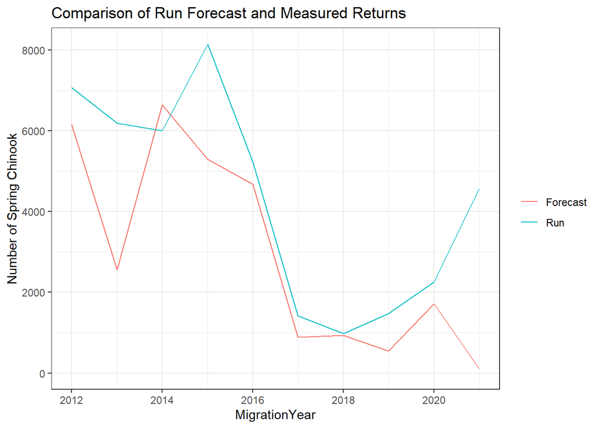

### References Beer, W.N., 2007. Run timing of adult Chinook Salmon passing Bonneville Dam on the Columbia River, Seattle: Columbia Basin Research, White Paper, University of Washington.

```
Knudsen C.M., Johnston M.V., Schroder S.L., Bosch W.J., Fast D.E.,
  Strom C.R., 2011. Effects of Passive Integrated Transponder tags on
  smolt-to-adult recruit survival, growth, and behavior of hatchery
  spring Chinook Salmon. North Am. Journal of Fisheries Management 29:658-669, 2009

McDonald, T.L., S.C. Amstrup, and B.F.J. Manly. 2003.Tag loss can bias
  Jolly-Seber capture-recapture esti-mates. Wildlife Society Bulletin 31:814-822.

Prentice, E.F., D.J. Maynard, S.L. Downing, D.A. Frost,M. S. Kellett,
  D. A. Bruland, P. Sparks-McConkey, F.W. Waknitz, R. N. Iwamoto, K. McIntyre,
  and N.Paasch. 1994. Comparison of long-term effects of PIT tags and CW tags
  on coho salmon (Oncorhynchus kisutch).Pages 123-137 in A study to determine
  the biological feasibility of a new fish tagging system.
```